# Review

CPT James Gallagher

March 14, 2018

```r
library(CorpEx)
library(tictoc)
data("July_Articles")
```

This evaluation will be a function by function evaluation with an overall analysis at the end. The data will be conducted using a condensed dataset of 100 observations, and in instances where that condensed dataset fails, then the whole dataset will be used.

## Function by Function definition

### * `keyword.corpus()` & `iso.date()`

First we will use the two given functions to generate two smaller datasets. Additionally, we will generate a third random dataset of 100 documents to evaluate the functions. This will allow us to ensure that we are using the functions on a variety of inputs and generating appropriate outputs without errors.

```r
###Random 100 articles
set.seed(123)
condensed <- July_Articles[sample(x = July_Articles$ArticleNo, size = 100, replace = F),]

## keyword Corpus
hurricane <- keyword.corpus(July_Articles, keyword = "hurricane")


### date time corpus

july4th <- iso.date(July_Articles, Beg.date = "4july2017", End.date = "4july2017")
```

This generates 3 different datasets.

### * `word.Assocs()`

```r
tryCatch(word.Assocs(condensed, "trump", corlimit = 0.6),
         error = function(e) e)
```

```
## <Rcpp::exception in mutate_impl(.data, dots): Column `data.td$ArticleNo` must be length 31873 (the number of rows) or one, not 100>
```

```r
tryCatch(word.Assocs(hurricane, "hurricane", corlimit = 0.6),
         error = function(e) e)
```

```
## <Rcpp::exception in mutate_impl(.data, dots): Column `data.td$ArticleNo` must be length 87510 (the number of rows) or one, not 145>
```

```r
tryCatch(word.Assocs(july4th, "president", corlimit = 0.6),
         error = function(e) e)
```

```
## <Rcpp::exception in mutate_impl(.data, dots): Column `data.td$ArticleNo` must be length 192698 (the number of rows) or one, not 641>
```

The output that should occur is a time series line plot of words associated with the term. However, an error occurs and no plot is generated. Copying the example from the function call shows

```r
tic("Word Association from example")
tryCatch(word.Assocs(July_Articles, "hurricane", 0.6),
         error = function(e) e)
```

```
## <Rcpp::exception in mutate_impl(.data, dots): Column `data.td$ArticleNo` must be length 6974524 (the number of rows) or one, not 22025>
```

```r
toc()
```

```
## Word Association from example: 50.41 sec elapsed
```

However, another error message is generated.

### * `bigram.network()`

```r
tryCatch(bigram.network(condensed, 200),
         error = function(e) e)
```

```
## <simpleError in `$<-.data.frame`(`*tmp*`, circular, value = FALSE): replacement has 1 row, data has 0>
```

```r
tryCatch(bigram.network(hurricane, 200),
         error = function(e) e)
```

```
## <simpleError in `$<-.data.frame`(`*tmp*`, "circular", value = FALSE): replacement has 1 row, data has 0>
```

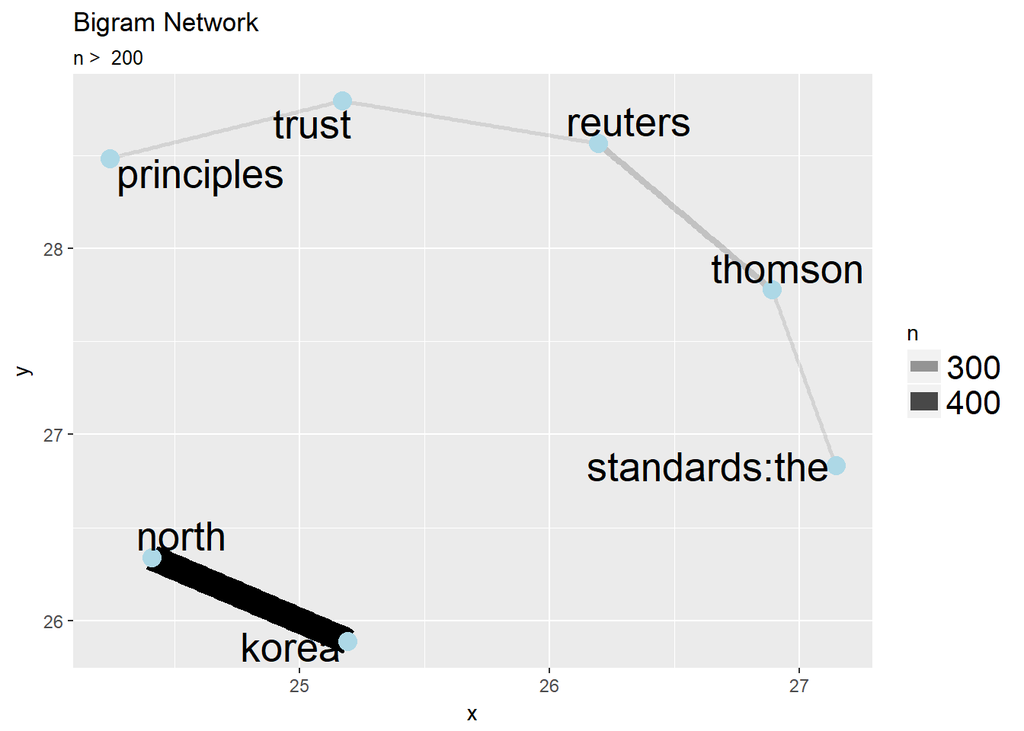

```r
tryCatch(bigram.network(july4th, 200),
         error = function(e) e)
```

This function also generates an error for 2 of the 3 data sets when calculating. Both of the two that failed could be related to a small dataset size of 100 and 145. The `july4th` dataset consists of 641 which is a relatively larger dataset.

Using the entire dataset results in the following:

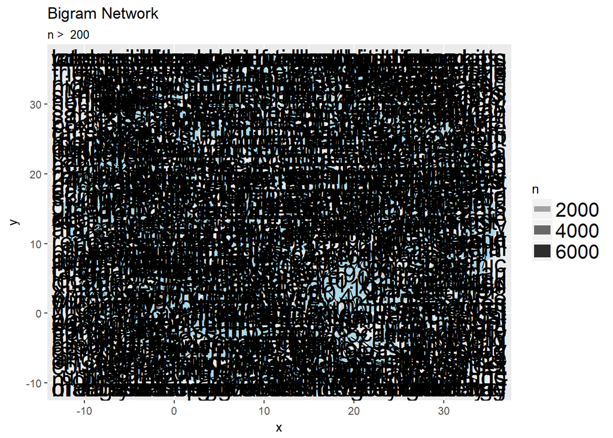

```r
tic("bigram network condensed")
tryCatch(bigram.network(July_Articles, 200),
         error = function(e) e)
```

```r
toc()
```

```
## bigram network condensed: 95.06 sec elapsed
```

This generates the network diagram of the associated bigrams. This plot generates a hard to read network diagram and also takes a significant time to calculate.

### * `corp.plot()`

This is intended to generate a line plot for the number of documents gathered per day.

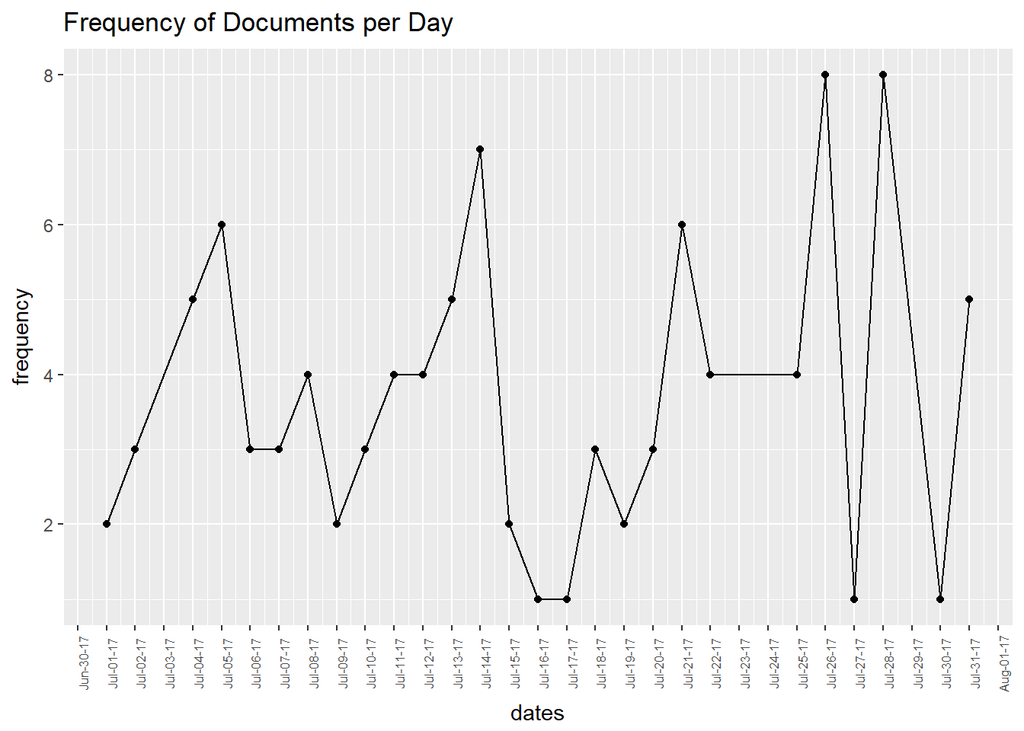

```r
tryCatch(corp.plot(condensed),
         error = function(e) e)
```

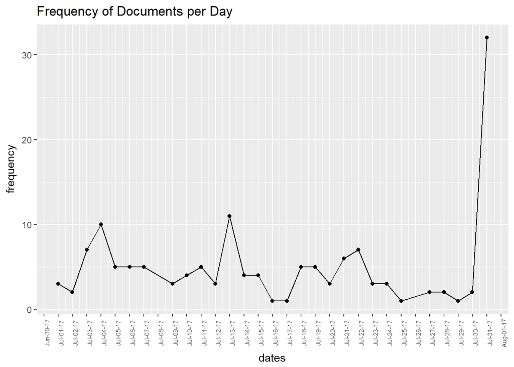

```r
tryCatch(corp.plot(hurricane),
         error = function(e) e)
```

```
## geom_path: Each group consists of only one observation. Do you need to
## adjust the group aesthetic?
```

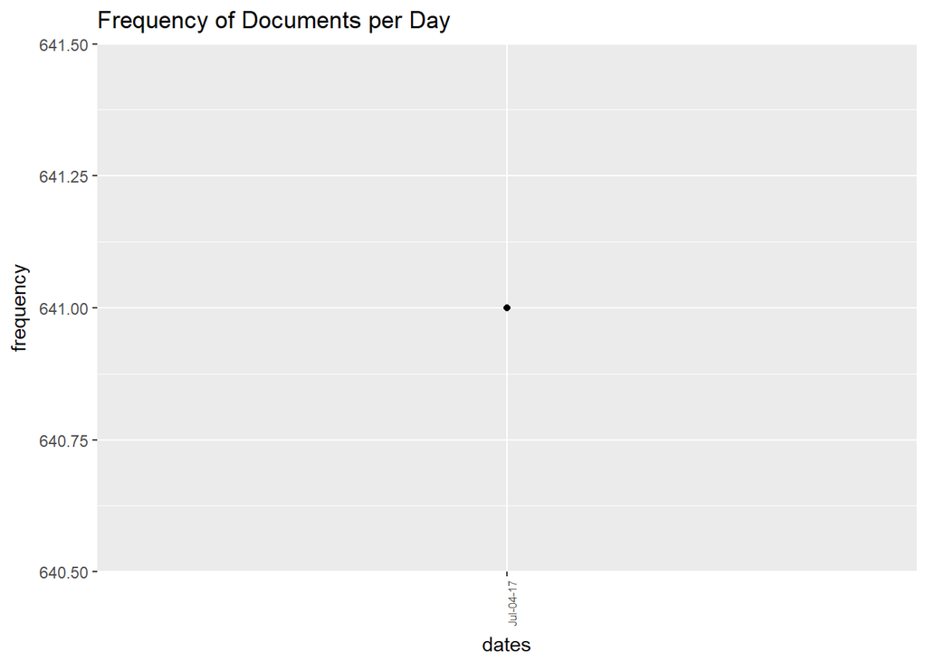

```r
tryCatch(corp.plot(july4th),
         error = function(e) e)
```

As the line plot shows, this graph generates quickly and looks to be accurate. The message for the July 4th dataset follows due to it consisting of datasets from only one day.

### * `cor.network()`

This is intended to generate a network graph of the most correlated word pairs down to a user defined `corlimit`

```r
tryCatch(cor.network(condensed, corlimit = 0.6),
         error = function(e) e)
```

```
## <simpleError in `$<-.data.frame`(`*tmp*`, "circular", value = FALSE): replacement has 1 row, data has 0>
```

[figure not shown]

```r
tryCatch(cor.network(hurricane, corlimit = 0.75),
         error = function(e) e)
```

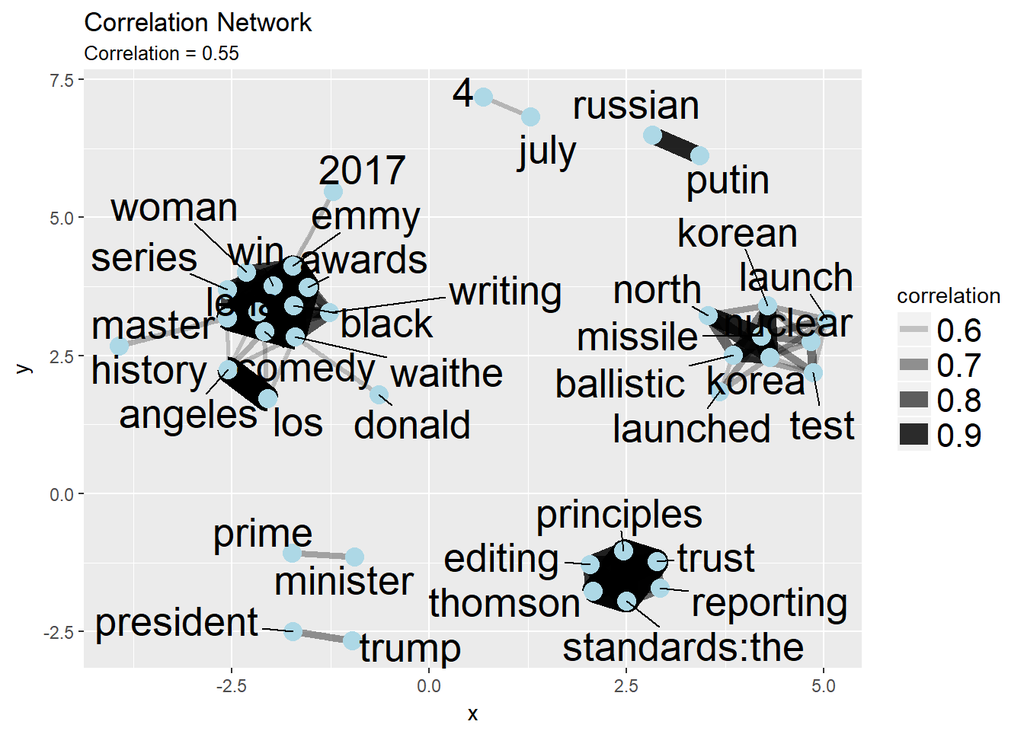

```r
tryCatch(cor.network(july4th, corlimit = 0.55),
         error = function(e) e)
```

The `condensed` dataset again fails. Using a small dataset like this generates issues, but the other two generated plotsthat made sense provided insight into which words were most commonly used together. This is useful and in line with the expected output.

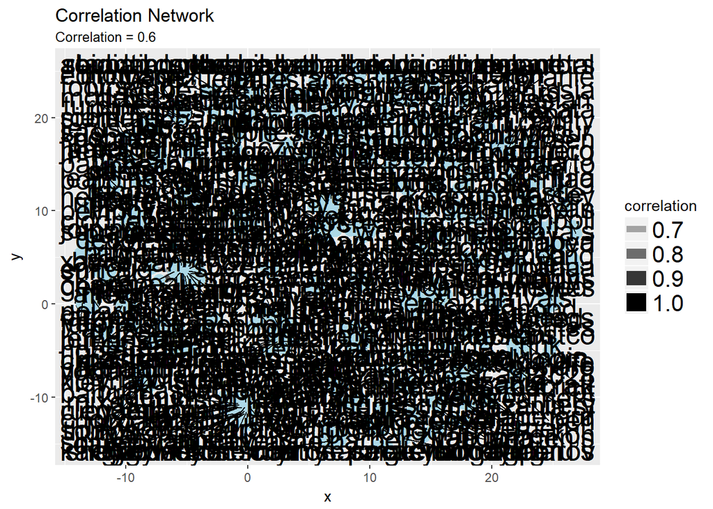

```r
tic("corpus line plot")
tryCatch(cor.network(July_Articles, corlimit = 0.6),
         error = function(e) e)
```

```r
toc()
```

```
## corpus line plot: 208.21 sec elapsed
```

This generates correctly, however with such a large dataset the plots are generally difficult to view and understand. Using the `keyword` or `iso.date` is critical to providing good insight into the data.

### * `kwsearch()

This function should generate a line graph with the number of times that the chosen key word is found on each day.

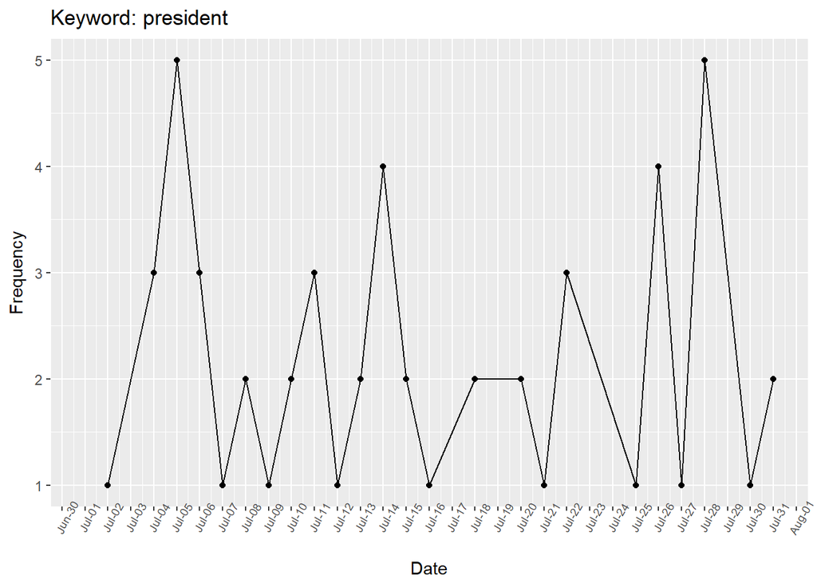

```r
tryCatch(kwsearch(condensed, "president"),
         error = function(e) e)
```

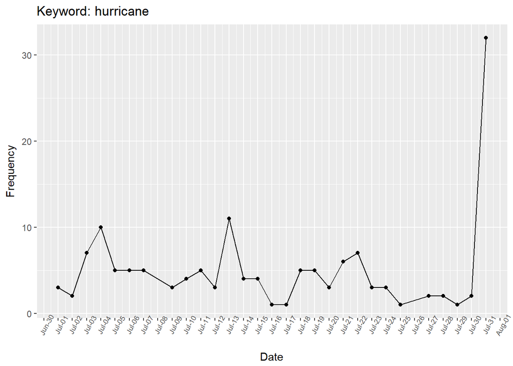

```r
tryCatch(kwsearch(hurricane, "hurricane"),
         error = function(e) e)
```

```r
tryCatch(kwsearch(july4th, "hurricane"),
         error = function(e) e)
```

[output not shown]

[figure not shown]

This function generates 3 different line plots and again identifies that the July 4th dataset only plots one data point because it consists of only one day’s worth of data.

### * `ngram.print()

This function should generate a table of associated n-grams.

```r
tryCatch(ngram.print(condensed, ngram = 2, num = 10),
         error = function(e) e)
```

```
## # A tibble: 11,849 x 2
##    bigram                    n
##    <chr>                 <int>
##  1 president trump          37
##  2 prime minister           26
##  3 white house              26
##  4 thomson reuters          25
##  5 reuters trust            23
##  6 standards:the thomson    23
##  7 trust principles         23
##  8 los angeles              21
##  9 supreme court            21
## 10 emmy awards              20
## # ... with 11,839 more rows
```

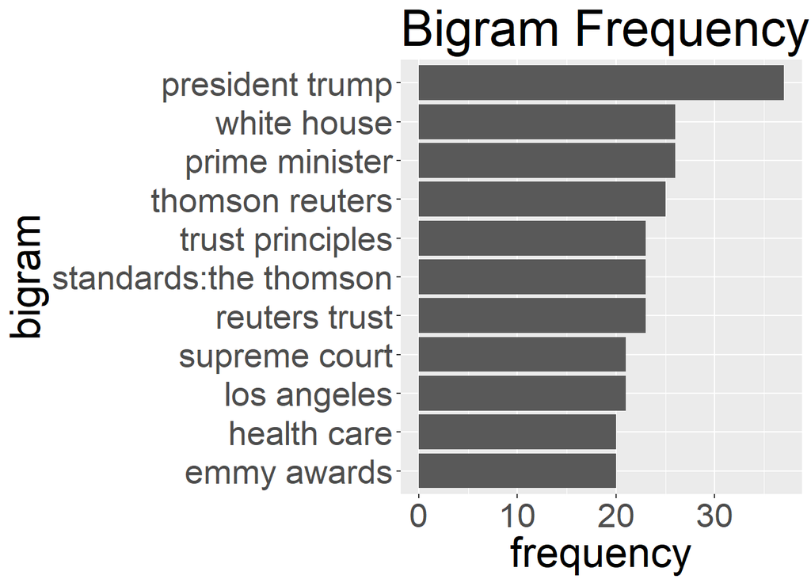

```r
tryCatch(ngram.print(hurricane, ngram = 2, num = 10),
         error = function(e) e)
```

```
## # A tibble: 20,277 x 2
##    bigram                n
##    <chr>             <int>
##  1 white house         187
##  2 getty ktla          138
##  3 historic trail      138
##  4 hurricane maria     138
##  5 maria left          138
##  6 puerto rico         138
##  7 los angeles         125
##  8 parris island       124
##  9 president trump      97
## 10 president trump's    96
## # ... with 20,267 more rows
```

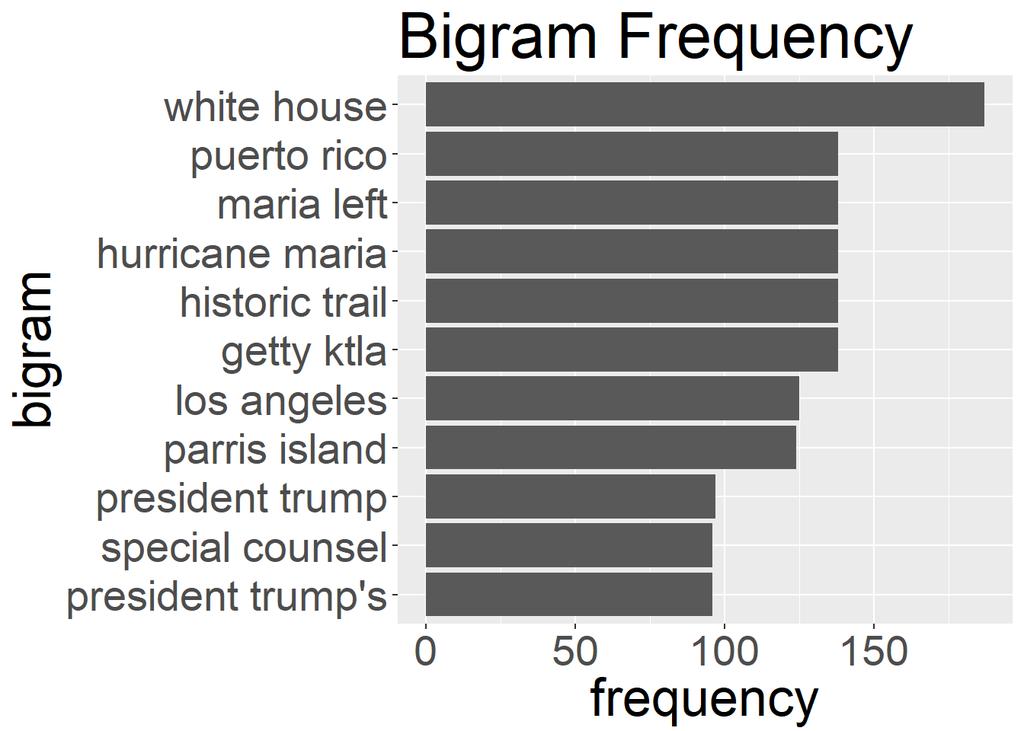

```r
tryCatch(ngram.print(july4th, ngram = 2, num = 10),
         error = function(e) e)
```

```
## # A tibble: 55,059 x 2
##    bigram                    n
##    <chr>                 <int>
##  1 north korea             495
##  2 thomson reuters         233
##  3 reuters trust           208
##  4 standards:the thomson   208
##  5 trust principles        208
##  6 ballistic missile       178
##  7 emmy awards             176
##  8 president trump         165
##  9 los angeles             155
## 10 south korea             140
## # ... with 55,049 more rows
```

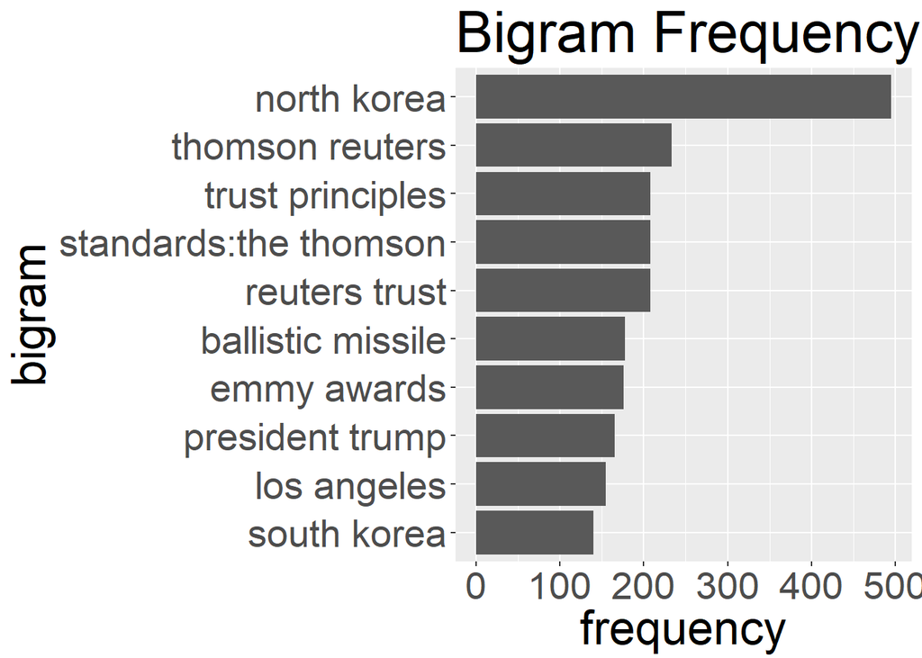

These plots and tables are useful outputs and follow from the generated table outputting to an equivalently sized bar chart in the plot. This data seems to be useful for the next step of merging terms.

### * `mergeTerms()

This can take the output from before and merge or remove terms deemed irrelevant. For example, “Thomson” appears to be a journalist for the “Reuters” news network. Therefore, we can eliminate his name since we do not need it for analysis.

```r
condensed1 <- mergeTerms(condensed, term = "Thomson", term.replacement = "")

hurricane1 <- mergeTerms(hurricane, term = "Thomson", term.replacement = "")

july4th1 <- mergeTerms(july4th, term = "Thomson", term.replacement = "")
```

We can check if this worked by doing a keyword search using that term

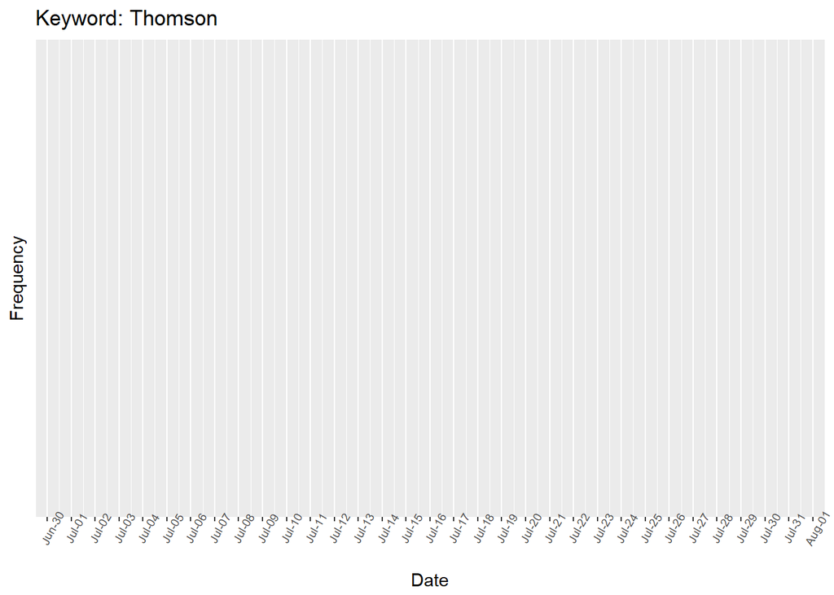

```r
kwsearch(condensed1, "Thomson")
```

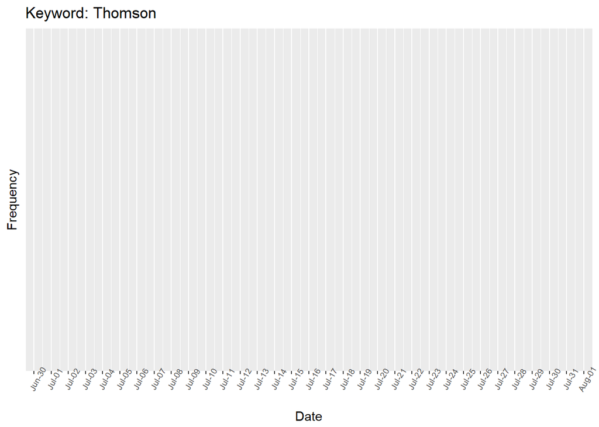

```r
kwsearch(hurricane1, "Thomson")
```

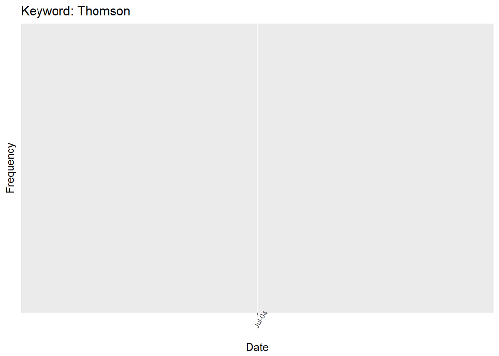

```r
kwsearch(july4th1, "Thomson")
```

We see that there are no occurrences of that term in the corpus. Therefore, the function appears to work.

## Overall Analysis

Overall, this package performs a number of valuable functions such as generating a smaller dataset based on keywords or a date range. Additionally, the correlation network and n-gram networks provide useful information about how words are paired together to relay information. Unfortunately, a few functions returned errors on function calls that should have evaluated properly. Additionally, these errors were not clear as to what caused the issue or provided recommendations on how to fix.

Another point for improvement would be the lack of a vignette or overall package documentation to explain the package. I had to use a lot of trial and error to understand the functions and which order to apply the functions to gain the most understanding of the data.

## Overall Grade: 45/50

While the package works on the whole, a few functions generate errors that are not clear as to why the errors are present. These errors seem relatively easy to correct and the package can be installed and without those features until they’re corrected.